# Ebola: building few models for Ebola

Pierre Nouvellet & Zulma Cucunuba

2017-12-12T14:00:00-00:00

This practical aims to illustrate the basics of **Ebola modelling** using R, with an emphasis on how the method works.

We will start with a basic model for Ebola. We will then illustrate how to account for an evolving context, e.g. implementation of control measures. Finally, we will explore basic principle of model fitting.

# Core Concepts

From the previous lecture, we will further develop these concepts:

- Compartmental models
- Flow diagrams and writing down a model
- Natural history of Ebola
- Control strategies
- Introduction to model fitting

## Required packages

```r
install.packages("deSolve", dep=TRUE)
install.packages("gridExtra", dep = TRUE)
```

Then load the packages using:

```r
library(deSolve)
```

# The basic Ebola model

- S : Susceptible humans
- E : Exposed humans
- I : Infected/Infectious humans
- R : humans recovered from infection (with life lasting immunity)

## The model

The code below will allow you to simulate an Ebola outbreak. But, can you understand it?

First make a flow diagram to connect the different compartments of the model according to the equation below.

On a line of code, anything after a ‘#’ is interpreted as a comment. At the moment the code below is not well commented on, try to comment the code appropriately.

```r
rm(list=ls())

Dyn.Ebola.Basic <- function (t, state, parameters) {


   with(as.list(c(state,parameters)), #local environment to evaluate derivatives
        {
          N <- S + E + I + R  # total number of individuals
          # Dynamics
          dS  <-  - S/N * beta * I                # suceptible and disease transmission
          dE <- S/N * beta * I - gamma * E        # exposed  - incubation period - new cases/progression to infectious
          dI <- gamma * E - sigma * I             # infectious cases and progression to final outcome

          dR <- (1 - p.cfr) * sigma * I           # recovered

          dDead <- p.cfr * sigma * I              # cumulative number of death
          dOnset <- gamma * E                     # cumulative number of new infections

          # List of outputs
          dx <- c(dS, dE, dI, dR, dDead, dOnset)
          list(dx)
        }
   )
}
```

Flow diagram to connect the different compartments of the model according to the equation below.

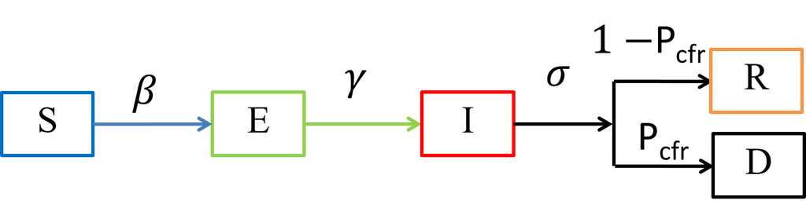

$$\ \frac{dS}{dt} = - \beta \frac {S_t I_t}{N_t}$$
$$\ \frac{dE}{dt} = \beta \frac {S_t I_t}{N_t} - \gamma E_t$$
$$\ \frac{dI}{dt} = \gamma E_t - \sigma I_t$$

$$\ \frac{dR}{dt} = (1-p_{CFR}) \sigma I_t$$

### The parameters

```r
# Parameters
T.lat   <- 10                   #   latency/ incubation period
gamma <- 1/T.lat            #   corresponding rate

T.outcome <- 12             # time until final outcome
sigma <- 1/T.outcome        # rate of progression to final outcome

p.cfr   <-  0.6                 #   case fatality ratio

R0 <- 1.5                   #   basic reproduction number
R.int <- 0.9                # Reproduction number after interventions are implemented

t.intervention = 25*7      # time of interventions at which reproduction number changes

# initial conditions
N <- 5e+5                   # population size
E0 <- 10                     # initial number of infected
```

Knowing the rate of transmission is typically very difficult without detailed studies. However, measurig the reproduction number may be easier.

From knowledge of the reproduction number, we can work out what is the rate of transmission ($\beta$).

### Numerically solve the system

We then need to solve the system numerically, i.e. using parameters values and starting conditions, we can predict the trajectories of each compartment over time.

The code below does that. Try to understand what is being done and comment the code appropriately.

```r
params <- c(gamma=gamma, sigma=sigma,
            p.cfr=p.cfr, beta=R0/T.outcome )   # parmeters of the model, involve


times  = seq(0, t.intervention, by=1)          # simulate every days until the time of intervention

# Starting conditions
xstart <- c(S = N-E0,E = E0,
            I = 0, R = 0,
            Dead = 0, Onset = 0)               # initial conditions

out <- as.data.frame(ode(y = xstart, times = times,
                         func = Dyn.Ebola.Basic, parms = params))   # numerically solve the system
```

### Plot some results

Can you interpret what is inside the dataframe ‘out’. you can view the dataframe by typing ‘View(out)’

The code below allow to visualise some key results.

Fill the axis and legend for the plots and comment the code. Interpret the results? Concept of exponential growth.

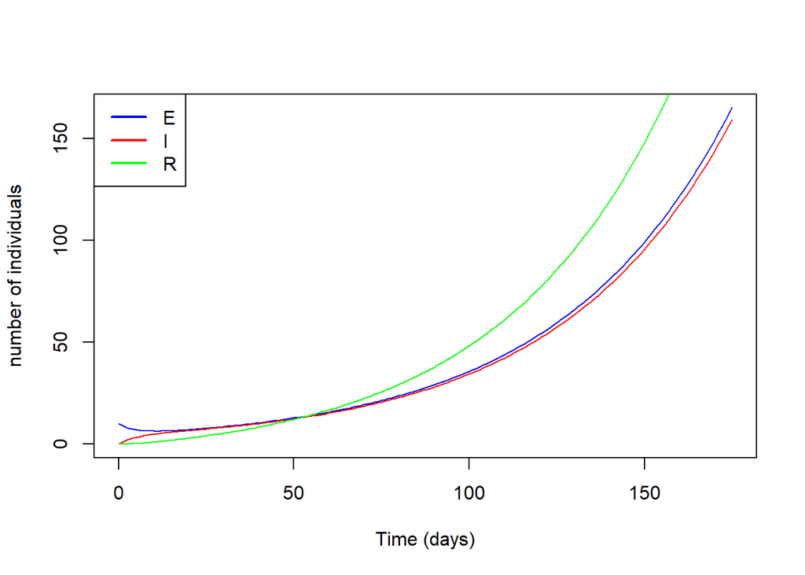

```r
# Checking the simulations
plot(out$time, out$E, col='blue',type='l',ylim = c(0,max(out$E)),
     xlab ='Time (days)', ylab = 'number of individuals')
lines(out$time, out$I, col='red')
lines(out$time, out$R, col='green')

legend('topleft',c('E','I','R'),lwd=2,col=c('blue','red','green'))
```

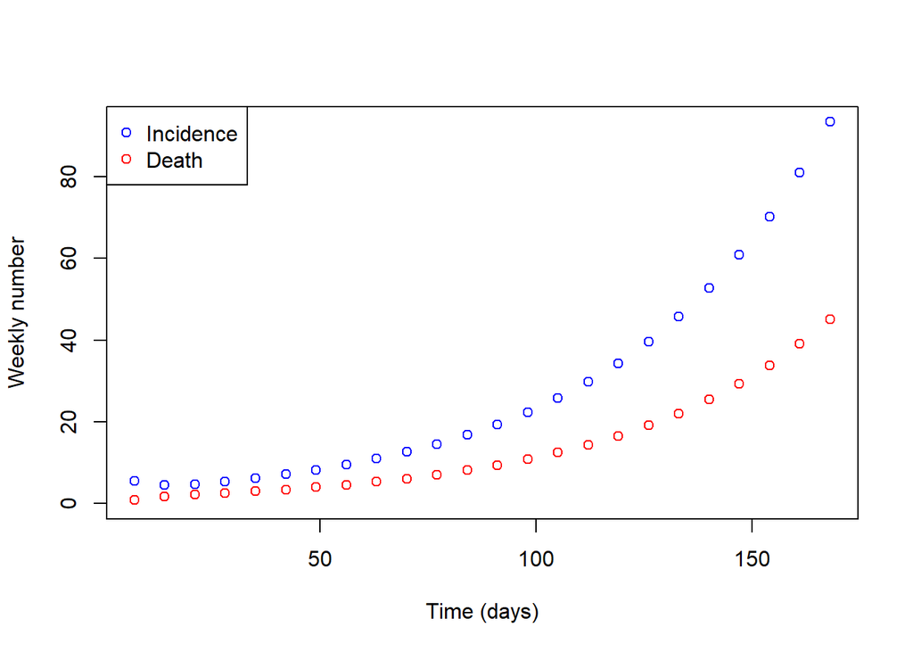

```r
# weekly incidence and weekly number of death
f <- seq(1,t.intervention,by=7)
time <- out$time[f]                # redefine the time
Weekly.onset <- diff(out$Onset[f])  # weekly number of new cases/ start of onset - remember out$onset is cumulative therefore out$onset[2]-out$onset[1] = incidence on day 2
Weekly.death <- diff(out$Dead[f])   # weekly number of new death

plot(time[-1], Weekly.onset, col='blue',type='p', ylim = c(0,max(Weekly.onset)),
     xlab ='Time (days)', ylab = 'Weekly number')
lines(time[-1], Weekly.death,type='p',col='red')

legend('topleft',c('Incidence','Death'),pch=1,col=c('blue','red'))
```

Fill the axis and legend for the plot. Interpret the results? Concept of exponential growth.

### Change the transmissibility

Now we want to simulate a change in transmissibility linked to an intervention.

Compare to the code above, what is changed in the code below?

Try to understand what is being done and comment the code appropriately.

```r
# Simulation 2

params2 <- c(gamma=gamma, sigma=sigma,
             p.cfr=p.cfr, beta=R.int/T.outcome) # parameters, beta=transmissibility is lowered


times2  = seq(t.intervention, 2*t.intervention, by=1)
# Starting conditions
xstart2 <- c(S = tail(out$S,1), E = tail(out$E,1),
             I = tail(out$I,1), R = tail(out$R,1),
             Dead = tail(out$Dead,1), Onset = tail(out$Onset,1))  # stating point = final previous state


out2 <- as.data.frame(ode(y = xstart2, times = times2,
                         func = Dyn.Ebola.Basic, parms = params2))  # numerically solve the new system
```

What is being done in the code above?

1- The reproduction number takes its second value, therefore the rate of transmission is decreased.

2- The new initial conditions are set to the previous final state of the system.

3- The model is then run.

Some results for the new output can be seen below. Try to comment the code and fill in relevant information in the graphs.

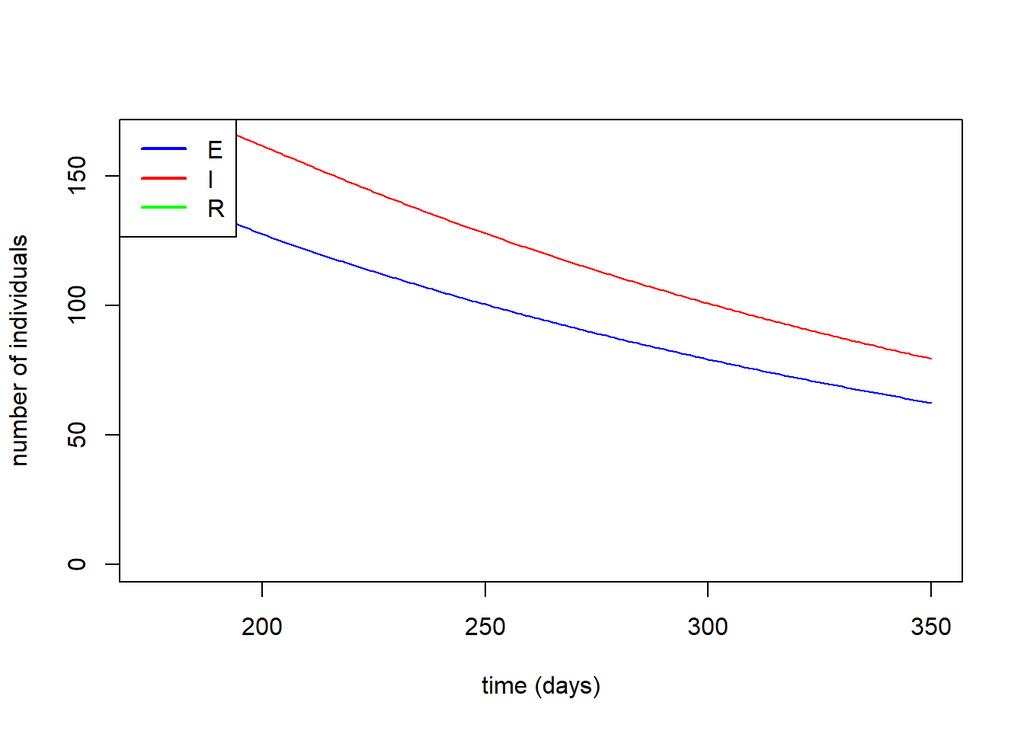

```r
# Checking the simulations
plot(out2$time, out2$E, col='blue',type='l',ylim = c(0,max(out$E)),
     xlab ='time (days)', ylab = 'number of individuals')
lines(out2$time, out2$I, col='red')
lines(out2$time, out2$R, col='green')

legend('topleft',c('E','I','R'),lwd=2,col=c('blue','red','green'))
```

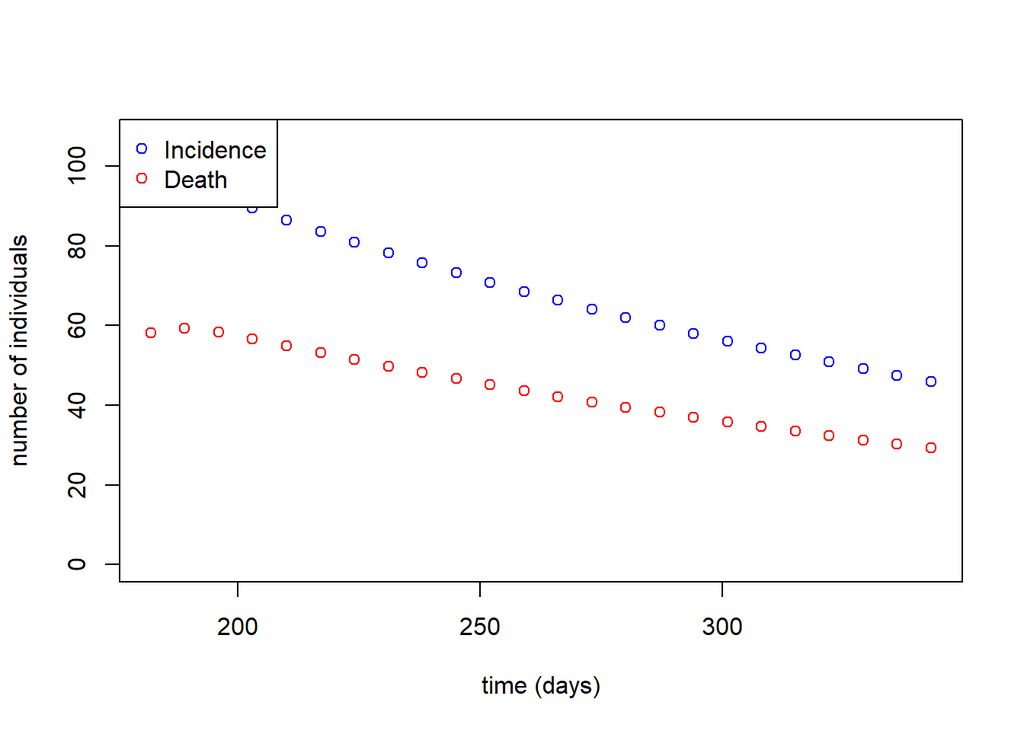

```r
# weekly incidence and weekly number of death
f <- seq(1,t.intervention,by=7)
time <- out2$time[f]
Weekly.onset <- diff(out2$Onset[f])
Weekly.death <- diff(out2$Dead[f])

plot(time[-1], Weekly.onset, col='blue',type='p', ylim = c(0,max(Weekly.onset)),
     xlab ='time (days)', ylab = 'number of individuals')
lines(time[-1], Weekly.death,type='p',col='red')

legend('topleft',c('Incidence','Death'),pch=1,col=c('blue','red'))
```

### Merging both situations

Can we plot both trajectory? Pre- and post-intervention? see below. Try to comment the code and fill in relevant information in the graphs.

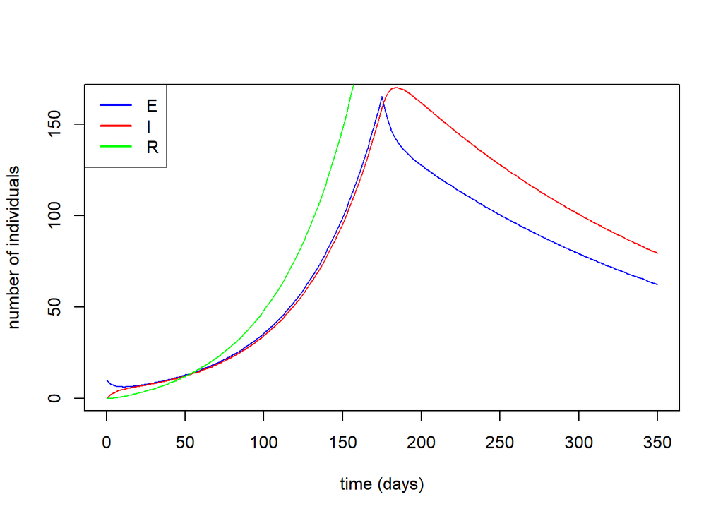

```r
## check full dynamics
# Checking the simulations
out3 <- rbind(out,out2[-1,])

plot(out3$time, out3$E, col='blue',type='l',ylim = c(0,max(out$E)),
     xlab ='time (days)', ylab = 'number of individuals')
lines(out3$time, out3$I, col='red')
lines(out3$time, out3$R, col='green')

legend('topleft',c('E','I','R'),lwd=2,col=c('blue','red','green'))
```

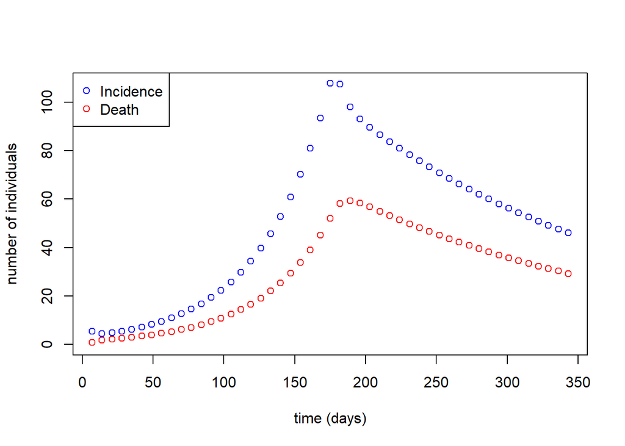

```r
# weekly incidence and weekly number of death
f <- seq(1,2*t.intervention,by=7)
time <- out3$time[f]
Weekly.onset <- diff(out3$Onset[f])
Weekly.death <- diff(out3$Dead[f])

plot(time[-1], Weekly.onset, col='blue',type='p', ylim = c(0,max(Weekly.onset)),
     xlab ='time (days)', ylab = 'number of individuals')
lines(time[-1], Weekly.death,type='p',col='red')

legend('topleft',c('Incidence','Death'),pch=c(1,1),col=c('blue','red'))
```

# Second model

We aim to reproduce the results above by calling the numerical solver only once. We also would like to compare our results to data.

Comment an interpret the code below:

What changed compared to the code used above?

First, we write a new model that will be able to account for changes in transmissibility.

Try to understand what is being done and comment the code appropriately.

```r
Dyn.Ebola.Basic2 <- function (t, state, parameters) {

   with(as.list(c(state,parameters)), #local environment to evaluate derivatives
        {
          N <- S + E + I + R  # total number of individuals

          beta <- ReproNb*sigma  # transmissibility rate as function of the current reproduction number

          # Dynamics
          dS  <-  - S/N * beta * I                # suceptible and disease transmission
          dE <- S/N * beta * I - gamma * E        # exposed  - incubation period - new cases/progression to infectious
          dI <- gamma * E - sigma * I             # infectious cases and progression to final outcome

          dR <- (1 - p.cfr) * sigma * I           # recovered

          dDead <- p.cfr * sigma * I              # cumulative number of death
          dOnset <- gamma * E                     # cumulative number of new infections

          dReproNb <- 0                           # changes in reproduction number

          # List of outputs
          dx <- c(dS, dE, dI, dR, dDead, dOnset, dReproNb )
          list(dx)
        }
   )
}
```

### Initial conditions

Then we set initial conditions and time varying parameters.

Try to understand what is being done and comment the code appropriately.

```r
times  = seq(0, 2 * t.intervention, by=1)          # simulate every days until the time of intervention
# Starting conditions
xstart <- c(S = N-E0,E = E0,
            I = 0, R = 0,
            Dead = 0, Onset = 0, ReproNb = R0)               # initial conditions

# event
eventdat <- data.frame(var = "ReproNb", time = t.intervention,
                       value = R.int, method = "rep")         # event dataframe: tell R that the variable reproNb will be replaced by R.int at time t.intervention


out <- as.data.frame(ode(y = xstart, times = times,
                         func = Dyn.Ebola.Basic2, parms = params,
                         events = list(data = eventdat)))   # numerically solve the system
```

### Plotting results

Finally we check the results and compare with observed data.

Try to comment the code and fill in relevant information in the graphs.

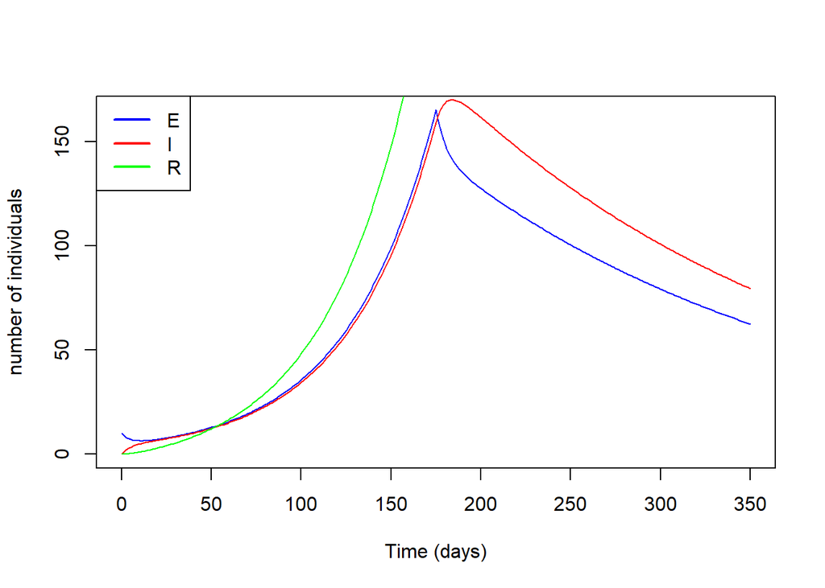

```r
# Checking the simulations
plot(out$time, out$E, col='blue',type='l',ylim = c(0,max(out$E)),
     xlab ='Time (days)', ylab = 'number of individuals')
lines(out$time, out$I, col='red')
lines(out$time, out$R, col='green')

legend('topleft',c('E','I','R'),lwd=2,col=c('blue','red','green'))
```

```r
# weekly incidence and weekly number of death
f <- seq(1,2*t.intervention,by=7)  # select start of the week
time <- out$time[f]                # redefine the time
Weekly.onset <- diff(out$Onset[f])  # weekly number of new cases/ start of onset - remember out$onset is cumulative therefore out$onset[2]-out$onset[1] = incidence on day 2
Weekly.death <- diff(out$Dead[f])   # weekly number of new death
```

```r
dat <- read.csv('onset_data.csv')
```

Once imported, the data should look like:

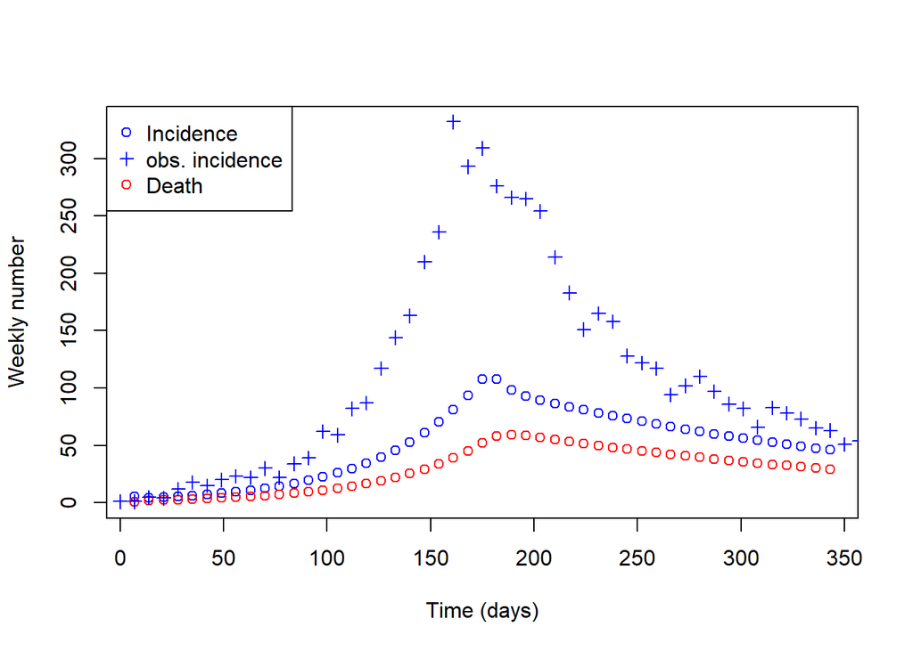

```r
plot(time[-1], Weekly.onset, col='blue',type='p', ylim = c(0,max(dat$incidence)),
     xlab ='Time (days)', ylab = 'Weekly number')
lines(time[-1], Weekly.death,type='p',col='red')

lines(dat$date, dat$incidence, type='p',pch=3, col='blue')

legend('topleft',c('Incidence','obs. incidence','Death'),pch=c(1,3,1),col=c('blue','blue','red'))
```

Now, try to modify:

- the initial number in the exposed class, and
- the reproduction post-intervention.

Re-run the model and observe the fit.

Try to obtain a better fit by changing paraemters.

### Exploration of fitting

Fitting manually to the data like above is tedious and not rigorous. We can explore a simple statistical method.

Let’s assume that we want to fit the initial number in the exposed class and the reproduction post-intervention. Clearly, we must find the values for those parameters such that our predictions matched best the observations.

Assuming that the incidence in a given week follows a Poisson distribution with mean given by our prediction:
$$P(I^{obs}_t|\theta) \propto Poiss(I^{pred}_t)$$
.

If each weekly incidences are assumed independent, the likelihood of the model could be written as:
$$L=\Pi [P(I^{obs}_t|\theta)]$$
.

in a very simple way, maximizing this likelihood will give us our best parameters.

### In practice

Interpret and comment the code below and add information on the plot.

In particular, what lighter color on the heat-graph represents? You can view the matrix L by typing ‘View(L)’ in the console.

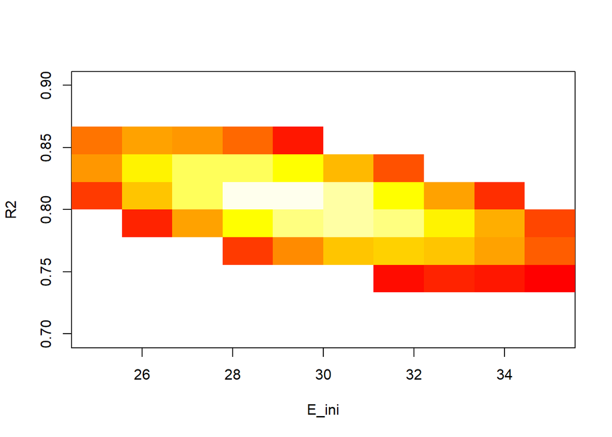

```r
E_ini <- seq(25,35,length=10)      # values of initial number Exposed for which the likelihood will be tested
R2 <- seq(.7,.9,length=10)         # values of post-intervention reproduction number for which the likelihood will be tested
L <- matrix(NA,length(E_ini),length(R2))   # matrix to contain all combination of likelihoods

for (i in 1:length(E_ini)){   # for one value of E, repeat over all possible values
  for (j in 1:length(R2)){    # for one value of r post-intervention, repeat over all possible values
    xstart <- c(S = N-E_ini[i],E = E_ini[i],
                I = 0, R = 0,
                Dead = 0, Onset = 0, ReproNb = R0)               # initial conditions, updated E_0

    eventdat <- data.frame(var = "ReproNb", time = t.intervention,
                           value = R2[j], method = "rep")          # new event dataframe with updated R

    out <- as.data.frame(ode(y = xstart, times = times,
                             func = Dyn.Ebola.Basic2, parms = params,
                             events = list(data = eventdat)))   # numerically solve the system

    Weekly.onset <- diff(out$Onset[f]) # weekly incidence

    L[i,j] <- sum(dpois(x = dat$incidence,lambda = Weekly.onset,log = TRUE))  # get the log-likelihood

  }
}
L[L < (max(L)*1.2)] <- NA          # remove all likelihood value that are below 1.2 of the maximum likelihood
image(E_ini,R2,L, col = heat.colors(30))  # plot the likelihood matrix / yellow indicates best fit
```

Now, from visual inspection of the graph, you can choose your best fit values for:

- the initial number in the exposed class, and
- the reproduction post-intervention,

### Plot the final fit

Then, we want to plot the observed versus the new predicted data.

Fill in the missing bits to be able to run the code below.

Try to understand and comment the code below:

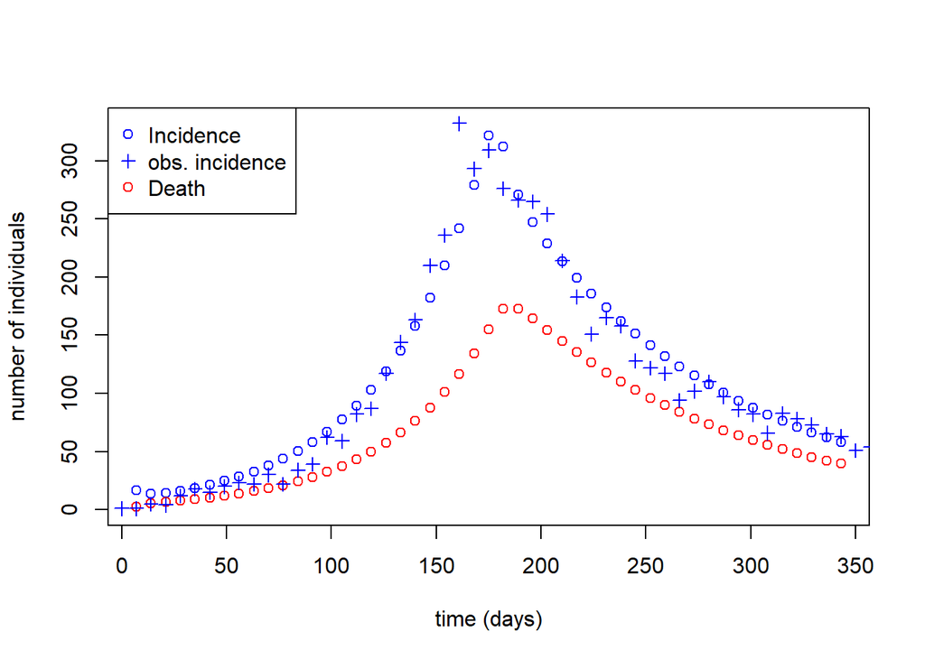

```r
# final
xstart <- c(S = N-E_ini[i],E = 30,
            I = 0, R = 0,
            Dead = 0, Onset = 0, ReproNb = 1.5)               # initial conditions, with best fit E_0

eventdat <- data.frame(var = "ReproNb", time = t.intervention,
                       value = .8, method = "rep")               # event with best fit post-intervention R

out <- as.data.frame(ode(y = xstart, times = times,
                         func = Dyn.Ebola.Basic2, parms = params,
                         events = list(data = eventdat)))   # numerically solve the system

# weekly incidence and weekly number of death
f <- seq(1,2*t.intervention,by=7)  # select start of the week
time <- out$time[f]                # redefine the time
Weekly.onset <- diff(out$Onset[f])  # weekly number of new cases/ start of onset - remember out$onset is cumulative therefore out$onset[2]-out$onset[1] = incidence on day 2
Weekly.death <- diff(out$Dead[f])   # weekly number of new death


# plot
plot(time[-1], Weekly.onset, col='blue',type='p', ylim = c(0,max(dat$incidence)),
     xlab ='time (days)', ylab = 'number of individuals')
lines(time[-1], Weekly.death,type='p',col='red')

lines(dat$date, dat$incidence, type='p',pch=3, col='blue')

legend('topleft',c('Incidence','obs. incidence','Death'),pch=c(1,3,1),col=c('blue','blue','red'))
```

# Final model

In the previous model, the intervention was modelled as a change in the reproduction number. Often it is useful to know more specifically what changed, i.e. this is the main advantage in building a ‘mechanistic model’.

For instance, if you know that isolated cases are not transmitting further, then an increase in ‘early’ isolation may help control the disease. A model can help quantify this and gain better intuition.

Retrospectively, if we know that such an intervention was implemented, then we can better understand to which extent it decreased transmission.

For instance we may know that the time to isolation decreased from **11.5 days** pre-intervention to a lower value, but we are unsure by how much.

See the code below can you interpret it?

First we write a new model:

```r
Dyn.Ebola.Basic3 <- function (t, state, parameters) {

   with(as.list(c(state,parameters)), #local environment to evaluate derivatives
        {
          N <- S + E + I + R  # total number of individuals
          # Dynamics
          sigma.h <- 1/delay_hosp                       # rate to go to hospital
          sigma <- 1/(delay_onset_outcome-delay_hosp)   # rate from hospital to final outcome


          dS  <-  - S/N * beta * I                # sucetpible & disease transmission (none from hospitalised cases)
          dE <- S/N * beta * I - gamma * E        # Exposed - incubation period - new cases / progression to infectious
          dI <- gamma * E - sigma.h * I           # infectious cases and going to hospital
          dIh <- sigma.h * I - sigma * Ih         # infectious cases isolated in hospital

          dR <- (1 - p.cfr) * sigma * Ih           # recovered

          dDead <- p.cfr * sigma * Ih              # cumulative number of death
          dOnset <- gamma * E                     # cumulative number of new infection

          ddelay_hosp <- 0                           # changes in reproduction number

          # List of outputs
          dx <- c(dS, dE, dI, dIh, dR, dDead, dOnset, ddelay_hosp )
          list(dx)
        }
   )
}
```

As before, try to:

- understand the code and comment it,
- draw a flow diagram,

-write dow the new equations of the system.

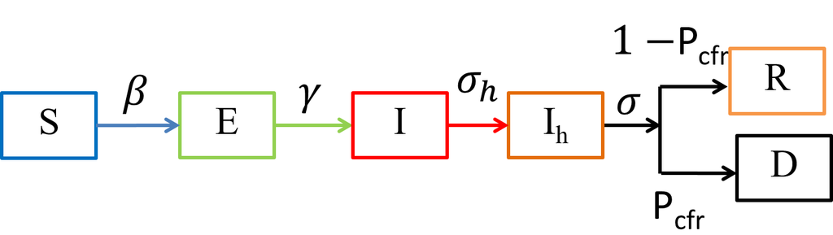

$$\ \frac{dS}{dt} = - \beta \frac {S_t I_t}{N_t}$$
$$\ \frac{dE}{dt} = \beta \frac {S_t I_t}{N_t} - \gamma E_t$$
$$\ \frac{dI}{dt} = \gamma E_t - \sigma_h I_t$$
$$\ \frac{dI_h}{dt} = \sigma_h I_t - \sigma I_{h,t}$$

$$\ \frac{dR}{dt} = (1-p_{CFR}) \sigma I_h,t$$

### New parameters

This should be very familiar, but comment on the code to make sure you understand everything.

```r
#==================  Parameters

T.lat   <- 10                   #   latency/ incubation period
gamma <- 1/T.lat            #   corresponding rate

T.outcome <- 12             # time until final outcome
T.hosp.1 <- 11.5            # time to hospitalisation
T.hosp.2 <- 5                # time to hospitalisation post-intervention

p.cfr   <-  0.6                 #   case fatality ratio

R0 <- 1.5                   #   basic reproduction number

# initial conditions
N <- 5e+5                   # population size
E0 <- 10                     # initial number of infected

# others parameters
t.intervention = 25*7      # time of intervention at which reproduction number changes
```

### Numerically solve the model

Then as before we run the model.

Again make sure you understand everything and comment the code.

What is being change post-intervention?

```r
#================== Simulation 1

params <- c(gamma=gamma, delay_hosp = T.hosp.1, delay_onset_outcome = T.outcome,
            beta = R0/T.outcome,
            p.cfr=p.cfr )   # parmeters of the model


times  = seq(0, 2 * t.intervention, by=1)          # simulated every days until the time of intervention
# Starting conditions
xstart <- c(S = N-E0,E = E0,
            I = 0, Ih = 0, R = 0,
            Dead = 0, Onset = 0, delay_hosp = T.hosp.1)               # initial conditions

# event
eventdat <- data.frame(var = "delay_hosp", time = t.intervention,
                       value = T.hosp.2, method = "rep")


out <- as.data.frame(ode(y = xstart, times = times,
                         func = Dyn.Ebola.Basic3, parms = params,
                         events = list(data = eventdat)))   # numerically solve the system
```

### Plotting results

Check the results by running the code below.

Fill in the comment and complete the graph information

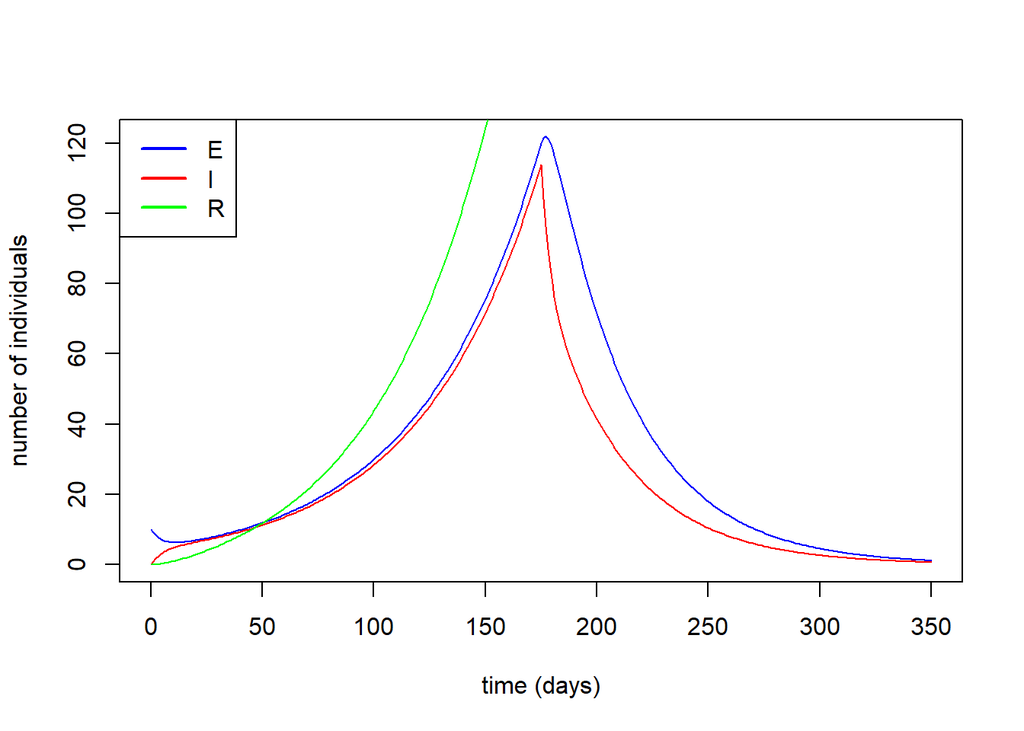

```r
# Checking the simulations
plot(out$time, out$E, col='blue',type='l',ylim = c(0,max(out$E)),
     xlab ='time (days)', ylab = 'number of individuals')
lines(out$time, out$I, col='red')
lines(out$time, out$R, col='green')

legend('topleft',c('E','I','R'),lwd=2,col=c('blue','red','green'))
```

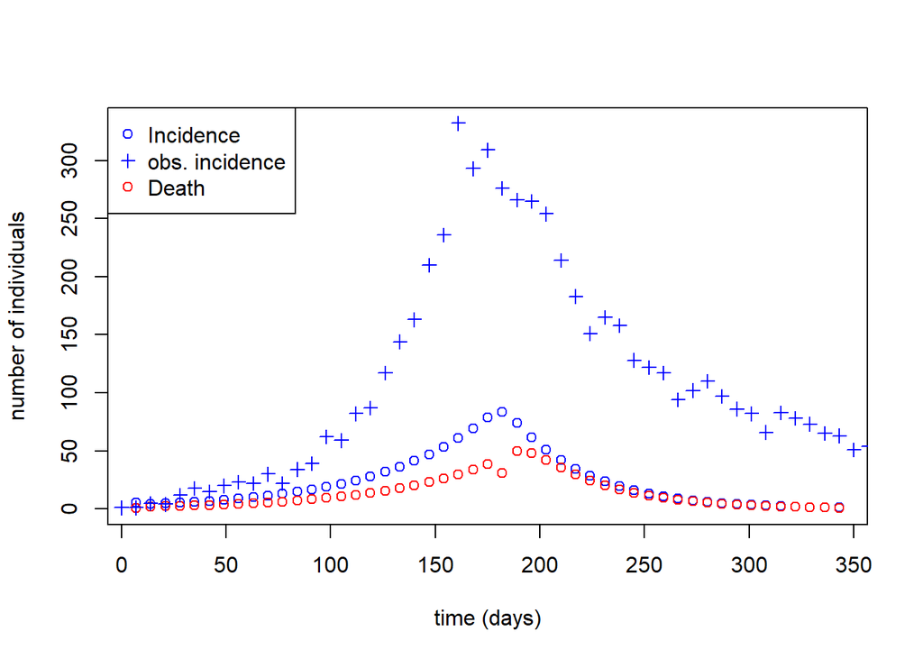

```r
# weekly incidence and weekly number of death
f <- seq(1,2*t.intervention,by=7)
time <- out$time[f]
Weekly.onset <- diff(out$Onset[f])
Weekly.death <- diff(out$Dead[f])

plot(time[-1], Weekly.onset, col='blue',type='p', ylim = c(0,max(dat$incidence)),
     xlab ='time (days)', ylab = 'number of individuals')
lines(time[-1], Weekly.death,type='p',col='red')

lines(dat$date, dat$incidence, type='p',pch=3, col='blue')

legend('topleft',c('Incidence','obs. incidence','Death'),pch=c(1,3,1),col=c('blue','blue','red'))
```

As before, try to modify:

- the initial number in the exposed class, and
- the time to hospitalisation post-intervention.

Re-run the model and observe the fit.

Your aim here is to fit the data better, and estimate by how much the time to isolation decreased after the intervention.

### Fitting

As before, fitting the model manually is not ideal.

Try to run the code below. Again, fill in the missing bits and interpret the code:

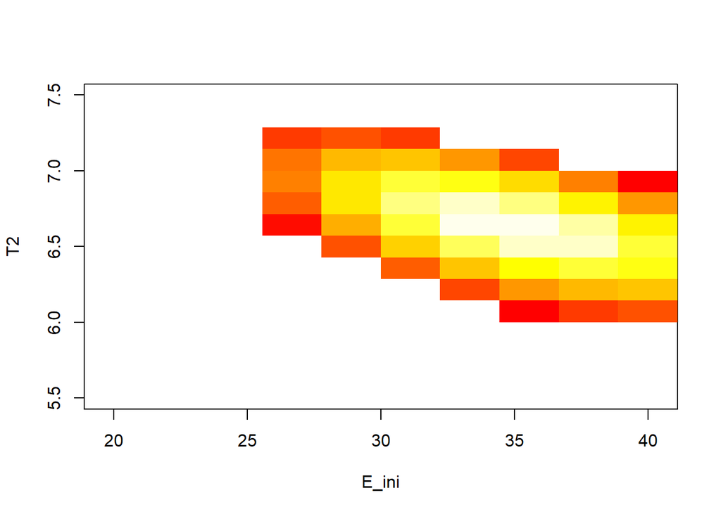

```r
###########################################################
#### get likelihood  ######################################
###########################################################

E_ini <- seq(20,40,length=10)  # values of initial number Exposed for which the likelihood will be tested
T2 <- seq(5.5,7.5,length=15) # values of post-intervention reproduction number for which the likelihood will be tested
L <- matrix(NA,length(E_ini),length(T2)) # matrix to contain all combination of likelihoods

for (i in 1:length(E_ini)){
  for (j in 1:length(T2)){
    xstart <- c(S = N-E_ini[i],E = E_ini[i],
                I = 0, Ih = 0, R = 0,
                Dead = 0, Onset = 0, delay_hosp = T.hosp.1)               # initial conditions, updated E_0

    eventdat <- data.frame(var = "delay_hosp", time = t.intervention,
                          value = T2[j], method = "rep")     # new event dataframe with updated R

    out <- as.data.frame(ode(y = xstart, times = times,
                             func = Dyn.Ebola.Basic3, parms = params,
                             events = list(data = eventdat)))   # numerically solve the system

    Weekly.onset <- diff(out$Onset[f]) # weekly incidence

    L[i,j] <- sum(dpois(x = dat$incidence,lambda = Weekly.onset,log = TRUE))  # get likelihood

  }
}
L[L < (max(L)*1.5)] <- NA
image(E_ini,T2,L, col = heat.colors(30))
```

We obtain best fit measure for the new time to hospitalisation.

### Final fit

Now fill in the code below to be able to run it and observe your new fit.

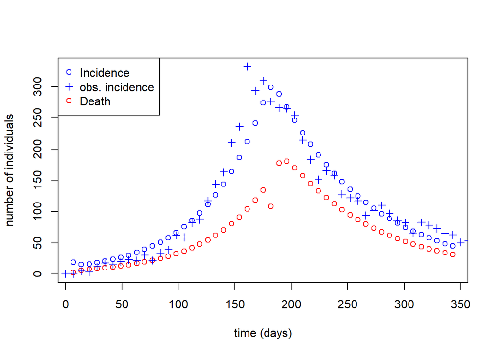

```r
# final
xstart <- c(S = N-E_ini[i],E = 35,
            I = 0, Ih = 0, R = 0,
            Dead = 0, Onset = 0, delay_hosp = T.hosp.1)               # initial conditions

eventdat <- data.frame(var = "delay_hosp", time = t.intervention,
                       value = 6.5, method = "rep")

out <- as.data.frame(ode(y = xstart, times = times,
                         func = Dyn.Ebola.Basic3, parms = params,
                         events = list(data = eventdat)))   # numerically solve the system

# weekly incidence and weekly number of death
f <- seq(1,2*t.intervention,by=7)
time <- out$time[f]
Weekly.onset <- diff(out$Onset[f])
Weekly.death <- diff(out$Dead[f])

# plot
plot(time[-1], Weekly.onset, col='blue',type='p', ylim = c(0,max(dat$incidence)),
     xlab ='time (days)', ylab = 'number of individuals')
lines(time[-1], Weekly.death,type='p',col='red')

lines(dat$date, dat$incidence, type='p',pch=3, col='blue')

legend('topleft',c('Incidence','obs. incidence','Death'),pch=c(1,3,1),col=c('blue','blue','red'))
```

### Explore further

you can explore further:

- try compute the full outbreak size,
- how many live could you save by intervening earlier (perhaps draw graph)?
- what is the influence of T.Hosp.2 on final size?

# About this document

## Contributors

- Pierre Nouvellet & Zulma Cucunuba: initial version

## Legal stuff

**License**: [CC-BY](https://creativecommons.org/licenses/by/3.0/) **Copyright**: Pierre Nouvellet, 2017